# Module Three Project

### b) Decision Tree Classifier

```r
dtc <- selected

dim(dtc)
```

```
## [1] 29965     9
```

Splitting the Data

We split my dataset into a training and testing set and then built my model. Given that the Target variable was binary therefore we built a classification model.

Splitting the Dataset into a Train and Test set with an 80:20 split

```r
sample_train<- sample(seq_len(nrow(dtc)), size = floor(0.80*nrow(dtc)))
sample_test <- sample(seq_len(nrow(dtc)), size = floor(0.20*nrow(dtc)))

training     <- dtc[sample_train, ]
test      <- dtc[sample_test, ]

dim(training)
```

```
## [1] 23972     9
```

```r
dim(test)
```

```
## [1] 5993    9
```

Training the Model we used the as.factor function for my target as the model was a Classification model

Finally we built our decision tree using cross validation to find the optimal model.

```r
library(caret)
```

```r
training$default_payment_next_month <- as.factor(training$default_payment_next_month)
test$default_payment_next_month <- as.factor(test$default_payment_next_month)


trctrl <- trainControl(method = "repeatedcv", number = 10, repeats = 5)
set.seed(123)
dtree_fit <- train(default_payment_next_month ~., data = training, method = "rpart",
                   parms = list(split = "information"),
                   trControl=trctrl,
                   tuneLength = 10)
```

```r
dtree_fit
```

```
## CART
##
## 23972 samples
##     8 predictor
##     2 classes: '0', '1'
##
## No pre-processing
## Resampling: Cross-Validated (10 fold, repeated 5 times)
## Summary of sample sizes: 21574, 21575, 21575, 21575, 21575, 21575, ...
## Resampling results across tuning parameters:
##
##   cp            Accuracy   Kappa
##   0.0003802281  0.8182629  0.3652573
##   0.0005228137  0.8199315  0.3694723
##   0.0005703422  0.8203069  0.3713068
##   0.0006337136  0.8206657  0.3720928
##   0.0006653992  0.8206657  0.3720928
##   0.0007604563  0.8205990  0.3696749
##   0.0008555133  0.8208743  0.3696547
##   0.0013307985  0.8213582  0.3679149
##   0.0024714829  0.8205322  0.3598771
##   0.1834600760  0.8003175  0.1843849
##
## Accuracy was used to select the optimal model using the largest value.
## The final value used for the model was cp = 0.001330798.
```

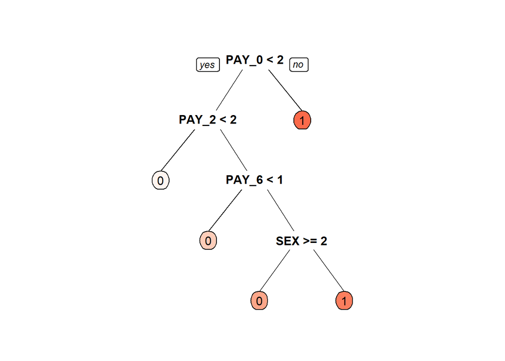

```r
library(rpart)
library(rpart.plot)
prp(dtree_fit$finalModel, box.palette = "Reds")
```

```r
#Model Evaluation We evaluated the model using the confusion matrix.

test_pred <- predict(dtree_fit, newdata = test)
confusionMatrix(test_pred, test$default_payment_next_month )
```

```
## Confusion Matrix and Statistics
##
##           Reference
## Prediction    0    1
##          0 4451  857
##          1  215  470
##
##                Accuracy : 0.8211
##                  95% CI : (0.8112, 0.8308)
##     No Information Rate : 0.7786
##     P-Value [Acc > NIR] : 2.428e-16
##
##                   Kappa : 0.3726
##
##  Mcnemar's Test P-Value : < 2.2e-16
##
##             Sensitivity : 0.9539
##             Specificity : 0.3542
##          Pos Pred Value : 0.8385
##          Neg Pred Value : 0.6861
##              Prevalence : 0.7786
##          Detection Rate : 0.7427
##    Detection Prevalence : 0.8857
##       Balanced Accuracy : 0.6541
##
##        'Positive' Class : 0
##
```

From the evaluation of the model , although the accuracy stands at 82% , the confusion matrix shows that many of the samples in the minority class are misclassified. This is due to the class imbalance in the dataset itself . Therefore we applied an oversampling technique to compensate for this.

Oversampling the imbalanced dataset

```r
library(ROSE)
# upsampling the dataset

data_balanced_over <- ovun.sample(default_payment_next_month ~ ., data = training, method = "over")$data
table(data_balanced_over$default_payment_next_month)
```

```
##
##     0     1
## 18712 18645
```

```r
#  fitting the upsampled dataset

data_balanced_over$default_payment_next_month <- as.factor(data_balanced_over$default_payment_next_month)
test$default_payment_next_month <- as.factor(test$default_payment_next_month)


trctrl <- trainControl(method = "repeatedcv", number = 10, repeats = 5)
set.seed(123)
dtree_fit <- train(default_payment_next_month ~., data = data_balanced_over, method = "rpart",
                   parms = list(split = "information"),
                   trControl=trctrl,
                   tuneLength = 10)


dtree_fit
```

```
## CART
##
## 37357 samples
##     8 predictor
##     2 classes: '0', '1'
##
## No pre-processing
## Resampling: Cross-Validated (10 fold, repeated 5 times)
## Summary of sample sizes: 33621, 33622, 33622, 33622, 33621, 33622, ...
## Resampling results across tuning parameters:
##
##   cp           Accuracy   Kappa
##   0.001072674  0.7043928  0.4085718
##   0.001179941  0.7039057  0.4075934
##   0.001340842  0.7034132  0.4066065
##   0.001483865  0.7019677  0.4037196
##   0.002038080  0.6978078  0.3953932
##   0.003164387  0.6961855  0.3921019
##   0.003513006  0.6947507  0.3892119
##   0.004451596  0.6927270  0.3851367
##   0.005282918  0.6885028  0.3766533
##   0.371037812  0.5760237  0.1508305
##
## Accuracy was used to select the optimal model using the largest value.
## The final value used for the model was cp = 0.001072674.
```

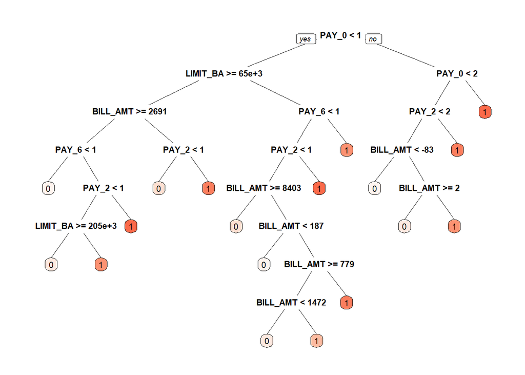

```r
prp(dtree_fit$finalModel, box.palette = "Reds")
```

```r
test_pred <- predict(dtree_fit, newdata = test)
confusionMatrix(test_pred, test$default_payment_next_month )
```

```
## Confusion Matrix and Statistics
##
##           Reference
## Prediction    0    1
##          0 3749  530
##          1  917  797
##
##                Accuracy : 0.7586
##                  95% CI : (0.7475, 0.7693)
##     No Information Rate : 0.7786
##     P-Value [Acc > NIR] : 0.9999
##
##                   Kappa : 0.3659
##
##  Mcnemar's Test P-Value : <2e-16
##
##             Sensitivity : 0.8035
##             Specificity : 0.6006
##          Pos Pred Value : 0.8761
##          Neg Pred Value : 0.4650
##              Prevalence : 0.7786
##          Detection Rate : 0.6256
##    Detection Prevalence : 0.7140
##       Balanced Accuracy : 0.7020
##
##        'Positive' Class : 0
##
```

### c) K-Means

```r
library(tidyverse)
library(cluster)
library(factoextra)
```

```r
# scaling the dataset
df <- scale(subset(selected, select = -c(default_payment_next_month)))
```

```r
# Trying with normalization technique
k_mean <- select(def, c(SEX,AGE,MARRIAGE,LIMIT_BAL,PAY_0,PAY_2,PAY_6,BILL_AMT1))
dim(k_mean)
```

```
## [1] 29965     8
```

```r
normalize <- function(x){
  return ((x-min(x)) / (max(x)-min(x)))
}
# Applying the Normalization function to the data
k_mean <- normalize(k_mean)
head(k_mean)
```

```
##         SEX       AGE  MARRIAGE LIMIT_BAL     PAY_0     PAY_2     PAY_6
## 1 0.1420597 0.1420786 0.1420589 0.1592169 0.1420597 0.1420597 0.1420580
## 2 0.1420597 0.1420803 0.1420597 0.2450111 0.1420580 0.1420597 0.1420597
## 3 0.1420597 0.1420872 0.1420597 0.2192728 0.1420580 0.1420580 0.1420580
## 4 0.1420597 0.1420898 0.1420589 0.1849551 0.1420580 0.1420580 0.1420580
## 5 0.1420589 0.1421069 0.1420589 0.1849551 0.1420580 0.1420580 0.1420580
## 6 0.1420589 0.1420898 0.1420597 0.1849551 0.1420580 0.1420580 0.1420580
##   BILL_AMT1
## 1 0.1454152
## 2 0.1443590
## 3 0.1671434
## 4 0.1823727
## 5 0.1494509
## 6 0.1973095
```

```r
#Elbow Method for finding the optimal number of clusters
set.seed(1123)
# Compute and plot wss for k = 2 to k = 15.
k.max <- 15
data <- k_mean
wss <- sapply(1:k.max,
              function(k){kmeans(data, k, nstart=50,iter.max = 1000 , algorithm="Lloyd" )$tot.withinss})
wss
```

```
##  [1] 491.02484 227.62166 159.98232 105.67297  78.44392  63.49600  52.01200
##  [8]  45.23994  39.38076  35.69474  32.46910  29.14203  26.75869  24.36809
## [15]  22.57359
```

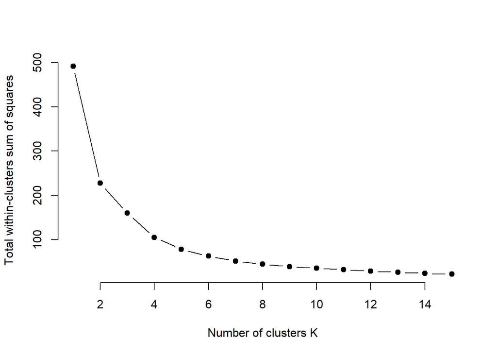

```r
plot(1:k.max, wss,
     type="b", pch = 19, frame = FALSE,
     xlab="Number of clusters K",
     ylab="Total within-clusters sum of squares")
```

K-Means with the scaled dataset below:

```r
# computing k- means clustering
k2 <- kmeans(df, centers = 2, nstart = 25)
str(k2)
```

```
## List of 9
##  $ cluster     : int [1:29965] 2 2 1 1 1 1 1 1 1 1 ...
##  $ centers     : num [1:2, 1:8] 0.0186 -0.1105 0.0034 -0.0202 -0.0266 ...
##   ..- attr(*, "dimnames")=List of 2
##   .. ..$ : chr [1:2] "1" "2"
##   .. ..$ : chr [1:8] "SEX" "MARRIAGE" "EDUCATION" "LIMIT_BAL" ...
##  $ totss       : num 239712
##  $ withinss    : num [1:2] 148794 43515
##  $ tot.withinss: num 192309
##  $ betweenss   : num 47403
##  $ size        : int [1:2] 25648 4317
##  $ iter        : int 1
##  $ ifault      : int 0
##  - attr(*, "class")= chr "kmeans"
```

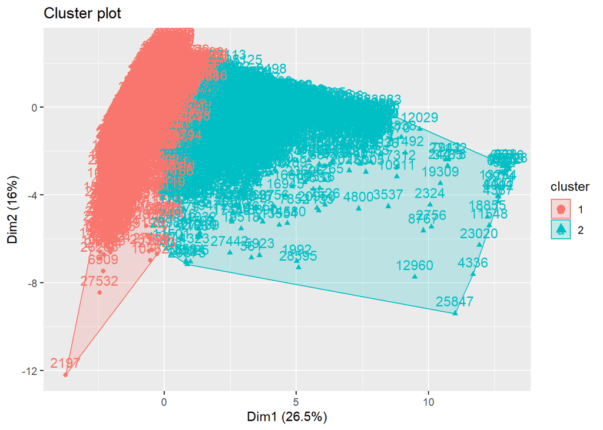

```r
#We can also view our results by using fviz_cluster. This provides a nice illustration of the clusters. If there are more than two dimensions (variables) fviz_cluster will perform principal component analysis (PCA) and plot the data points according to the first two principal components that explain the majority of the variance.

fviz_cluster(k2, data = df)
```

```r
#Verify results of clustering
table(k2$cluster,selected$default_payment_next_month)
```

```
##
##         0     1
##   1 21525  4123
##   2  1810  2507
```

## Conclusions

From our analysis, we concluded the following two major factors

Limit Balance - From our analysis demonstrates that the clients who defaulted on their payments had lower limit balances than the clients who paid their credit card bill.

Repayment Status - which means that just by looking at how late someone is on their payments in 1 month, we can tell if they will default or not. The pay delay by almost one month is the one outstanding followed by those who pay duly as their credit card as of and when it falls due as exhibited by the various count plots for different months.

## RECOMMENDATIONS

In general , in order to mitigate losses and prevent people from defaulting or falling behind on their credit card payments the bank should put measures that incentivise timely payment. For instance the bank should charge late fees for any payment made later than the day it was due.

Given that those aged between 20-40 made up the largest demographic of both the defaulters and the dataset in general the bank could put up measures that would help them prevent losses. For instance they could ask for proof of employment before issuing credit cards.

We recommend the Decision Trees model which performed better than the Logistic Regression Model.

Limit Balance - From our analysis demonstrates that the clients who defaulted on their payments had lower limit balances than the clients who paid their credit card bill.

Age - Those aged between 20-40 made up the largest demographic of both the defaulters and the dataset in general.

Repayment Status - which means that just by looking at how late someone is on their payments in 1 month, we can tell if they will default or not. The pay delay by almost one month is the one outstanding followed by those who pay duly as their credit card as of and when it falls due as exhibited by the various count plots for different months

More women defaulted from their payments than men however women made up more than half the entire population.

From the modeling bit, we recommend the decision tree which has a better performance.